# ECON4261 - Homework 1

# Part 1:

1.) The sample mean $\hat{\mu}$ is also a random variable, with normal distribution $\sim \mathcal{N}(\mu,\sigma^2/n)$. So the variance of $\hat{\mu}$ is given by $\hat{\sigma^2} = \sigma^2/2N$.

2.) See funciton “vartest”. This calculates the sample variance of each sample created in “draw_data”. For example, the i-th test (repetition) of my function “vartest” will store ${\sigma_i}^2 = (\hat{\mu_i} - \mu)^2$ and after the B-th repetition I will take the mean of my variance estimates using this formula: $\frac{1}{B}\sum_{i=1}^{B} {\sigma_i}^2$ and this is the result I return. Based on my formula from question 1, as $B \rightarrow \infty$ then $\hat{\sigma ^2} \rightarrow \frac{1^2}{2*100} = 0.005$.

```r
draw_data <- function(mu,sig,rho,N) {
  X = matrix(0,N,2) #<- this is an N x 2 array that will store X_{n,1} in the n-th row and 1st column, and X_{n,2} in the second column of the n-th row
  eps_1 = rnorm(N,0,sig) #<- this command simulates N random realizations from a normal with mean zero and standard deviation sig. The n-th entry of this vector will be taken as the valuate of epsilon_{n,2}
  eps_2 = rnorm(N,0,sig) #<- another vector of normal random variables, this time the n-th entry is epsilon_{n,2}
  X[,1] = mu + eps_1 #<- This command sets of the value of the first column of X (i.e. each X_{n,1} for n=1,...N)
  X[,2] = mu + rho*eps_1 + eps_2 #<- And setting the value for the second column (each X_{n,2} for n=1,...,N)
  X
}


montecarlo <- function(mu,sig,rho,N,B) {
  mu_hat = matrix(0,B) #<- this will store an estimate from each trial
  for (b in 1:B) {
    xb = draw_data(mu,sig,rho,N) #<- simulate a sample of size N
    mu_hat[b] = sum(xb) / (2*N) #<- store the estimator for this trial
  }
  mu_hat
}

vartest <-function(mu,sig,rho,N,B) {
  mu_hat_m = montecarlo(mu,sig,rho,N,B)
  var_m = matrix(0,B) #stores a value for the sample variance of each trial
  for (b in 1:B) {
    var_m[b] = (mu_hat_m[b] - mu)^2 #calculates, (Xi - Xn)^2, xn is the mean (mu = 2) and xi is the estimator mean from the montecarlo test
  }
  print(sum(var_m)/B)
}

vartest(2,1,0,100,10)
```

```
[1] 0.002202864
```

```r
vartest(2,1,0,100,50)
```

```
[1] 0.006897773
```

```r
vartest(2,1,0,100,100)
```

```
[1] 0.005311116
```

```r
vartest(2,1,0,100,1000)
```

```
[1] 0.005005902
```

3.) When $\rho = 0.5$ then our variance will be higher because the random variable $X_{n,2} = \mu + \rho\times\epsilon_{n,1} + \epsilon_{n,2}$ and the variance of $\epsilon_{n,1}$ and $\epsilon_{n,2}$ is given by $\sim \mathcal{N}(0,\sigma^2)$

```r
vartest(2,1,0.5,100,1000)
```

```
[1] 0.007536483
```

4.) The confidence interval works for when $\rho = 0$. I believe that the confidence interval still works for when $\rho = 0.5$, the only difference is that there is different variance levels when $\rho = 0.5$ which may create a less accurate confidence interval at lower levels of “B”.

```r
# ci_func <- function(mu,sig,rho,N,B,alpha) { #ci_func seems to not work correctly, see ci_func2
#   mu_hat = matrix(0,B) #<- this will store an estimate from each trial
#   for (b in 1:B) {
#     xb = draw_data(mu,sig,rho,N) #<- simulate a sample of size N
#     mu_hat[b] = sum(xb) / (2*N) #<- store the estimator for this trial
#   }
#
#   standard_error = sd(mu_hat)/(sqrt(B))
#   t_score = qt(p=alpha/2, df = (B-1), lower.tail=F)
#   margin_error = t_score * standard_error
#
#   print(c("Upper bound:", mu-margin_error))
#   print(c("Lower bound:", mu+margin_error))
# }
# ci_func(2,1,0,100,1000,0.05) #alpha = 0.05, a 95% CI
# ci_func(2,1,0.5,100,1000,0.05) #alpha = 0.05, a 95% CI

ci_func2 <- function(mu,sig,rho,N,B) {
  mu_hat = as.data.frame(montecarlo(mu,sig,rho,N,B))
  l_model <- lm(mu_hat[,1] ~ 1, mu_hat)
  confint(l_model, level=0.95)
}
print("95% CI for when rho = 0:")
```

```
[1] "95% CI for when rho = 0:"
```

```r
ci_func2(2,1,0,100,1000)
```

```
               2.5 %   97.5 %
(Intercept) 1.994987 2.003495
```

```r
print("95% CI for when rho = 0.5:")
```

```
[1] "95% CI for when rho = 0.5:"
```

```r
ci_func2(2,1,0.5,100,1000)
```

```
               2.5 %   97.5 %
(Intercept) 1.998974 2.009874
```

# Part 2:

```r
library(tidyverse)
```

1.)

```r
D <- read.csv("cps-econ-4261.csv") %>%
  filter(YEAR<=2018 & YEAR>=2014) %>%
  mutate(EARNWEEK = na_if(EARNWEEK,9999.99),
         UHRSWORKT = na_if(na_if(na_if(UHRSWORKT,999),997),0),
         HOURWAGE = na_if(HOURWAGE,999.99))

D <- mutate(D,Wage = case_when(PAIDHOUR==1 ~ EARNWEEK/UHRSWORKT,PAIDHOUR==2 ~ HOURWAGE)) %>%
  filter(!is.na(Wage))
```

2.)

```r
D %>%
  group_by(AGE) %>%
  summarize(m = mean(log(Wage)))
```

| AGE | m |
| --- | --- |
| 18 | 2.182742 |
| 19 | 2.283514 |
| 20 | 2.300554 |
| 21 | 2.354652 |
| 22 | 2.437761 |
| 23 | 2.525266 |
| 24 | 2.576274 |
| 25 | 2.706083 |
| 26 | 2.749936 |
| 27 | 2.792358 |

[output cut: 38 more lines]

```r
D %>%
  group_by(SEX) %>%
  mutate(SEX = factor(SEX,levels=c(1,2),labels=c("Male","Female"))) %>%
  summarize(m = mean(log(Wage)))
```

| SEX | m |
| --- | --- |
| Male | 3.001543 |
| Female | 2.846485 |

```r
D %>%
  mutate(kids = NCHILD>0) %>%
  mutate(kids = factor(kids, labels=c("Has no children", "Has children"))) %>%
  group_by(kids) %>%
  summarise(m = mean(log(Wage)))
```

| kids | m |
| --- | --- |
| Has no children | 2.864923 |
| Has children | 2.995209 |

```r
NA
NA
NA
```

3.)

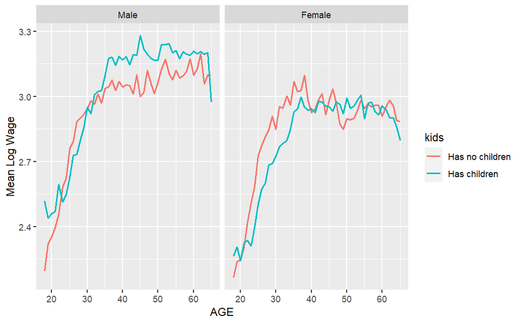

```r
D %>%
  mutate(kids = NCHILD>0) %>%
  mutate(kids = factor(kids, labels=c("Has no children","Has children")), SEX=factor(SEX,levels=c(1,2),labels=c("Male","Female"))) %>%
  group_by(AGE,SEX,kids) %>%
  summarize(m = mean(log(Wage))) %>%
  ggplot(aes(x=AGE,y=m,color=kids)) + geom_line(size=0.8) + ylab("Mean Log Wage") + facet_grid(. ~ SEX)
```

Looking at women between the ages of 20-40, you can see that women with children earn less than women without children. This trend does not exist for men. The wage gap between women with and without children closes around 40. This may imply that women who choose to have children are more financially penalized than men who have children. This may be due to a reluctance to hire pregnant women, and/or some women staying out of the workplace to raise their kids until their kids are older.